# Unsupervised Learning

Malo Jan & Luis Sattelmayer

2026-01-22

## Outline

1. What is unsupervised learning?
2. Topic Modeling
3. Word Embeddings

# Unsupervised Learning

## What is unsupervised learning?

- Unsupervised learning is a type of machine learning that is used to find hidden patterns in data
- Unlike supervised learning, unsupervised learning does not require labeled data, i.e. no human intervention (at first)
- Example applications: clustering, dimensionality reduction, anomaly detection, and topic modeling

## Clustering & Dimensionality Reduction

- Clustering is a type of unsupervised learning that is used to group similar data points together
  - kNN, k-means, hierarchical clustering
  - relies on assumption that data points relate to latent groups
- Dimensionality reduction is a technique used to reduce the number of features in a dataset while preserving the most important information
  - PCA, t-SNE, UMAP
  - relies on assumption that data points lie on a lower-dimensional manifold

## Unsupervised Learning as induction

- Inductive reasoning starts with specific observations (e.g., raw data points) and moves toward a broader understanding or model of the data
- Unsupervised learning is a form of inductive reasoning that is used to discover patterns in data without human intervention
- A posteriori, we have to interpret the unsupervised classification(s)
  - clustering: what do the clusters represent?
  - dimensionality reduction: what are the most important features?

## How does this relate to ML?

- Unsupervised learning is a crucial part of the machine learning pipeline
  - preprocess data, identify patterns, and reduce the dimensionality of data
- Often used in combination with supervised approaches to improve the performance of predictive models
  - topic modeling –> identify topics in a collection of documents, which can then be used as labels in a supervised learning model
  - word embeddings –> represent words as dense vectors, which can then be used as input to a supervised learning model

# Topic Modeling

## What is topic modeling?

- Topic modeling is a type of unsupervised learning that is used to discover hidden patterns in a collection of documents
- It is used to identify topics that frequently occur in a collection of documents
- The most common topic modeling technique is Latent Dirichlet Allocation (LDA) (Blei, Ng, and Jordan 2003)

## Latent Dirichlet Allocation (LDA)

- LDA is a generative probabilistic model that assumes that
  1. each document is a mixture of topics
  2. each topic is a distribution over words
- Goal:infer the topics that best explain the observed documents
- LDA widely used in text mining, information retrieval, and natural language processing

## LDA

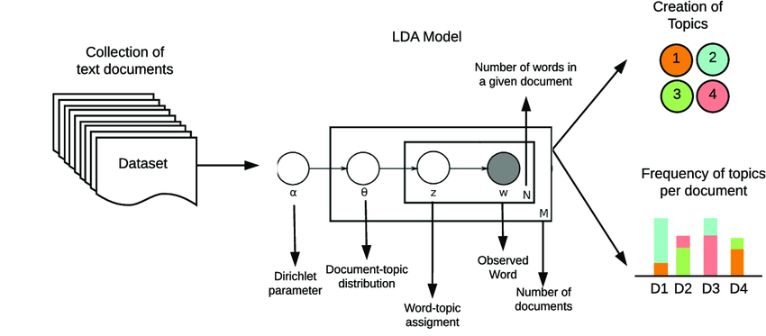

## Structural Topic Modeling

- Structural Topic Modeling (STM) (Roberts et al. 2014) is an extension of LDA that incorporates document metadata
- Allows the inclusion of covariates in the model, which can help to explain the relationship between topics and document metadata
- If you have metadata critical to your research questions (understanding how topics vary across groups, over time, or in relation to specific attributes)

## LDA as a BoW approach

- Topic models still remains a Bag of Words approach
- It ignores:
  - word order
  - context
  - syntax
- LDA enhances the basic BoW model by assuming that documents are mixtures of topics, and topics are distributions over words

## Gonzatti and Völker (2025)

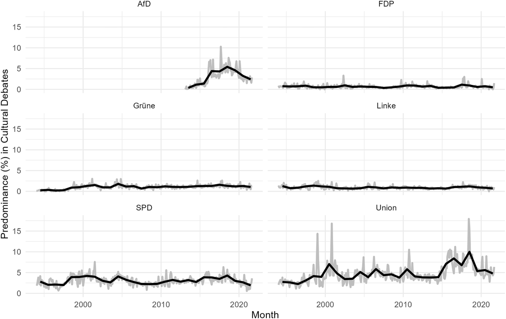

## Gonzatti and Völker (2025)

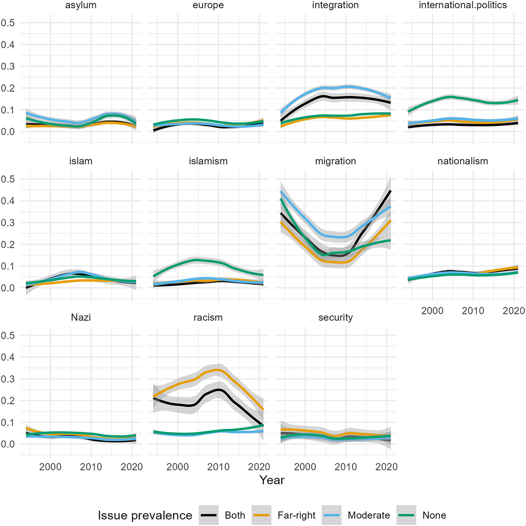

# Word Embeddings

## What are word embeddings?

- ”You shall know a word by the company it keeps” (Firth 1957)
- Word embeddings are dense vector representations of words in a high-dimensional space
- They are learned from large text corpora using *unsupervised* learning techniques
- Words are represented as “ordered sequences: the occurrence of a given word(s) is used to predict the occurrence of the next one(s)” (Rodriguez and Spirling 2022)
- To be simple, imagine a low-dimensional space where words are distributed according to their semantic similarity: the embeddings are their coordinates
- Words that have a similar meaning will have similar vectors, possible to measure distance, similarity and basic arithmetic: King - Man + Woman = Queen
- Breakthrough in NLP in 2013 estimate of word embeddings from neural networks with word2vec (Mikolov et al. 2013)
  - Predict occurence of a word given a context window: How likely is it that legislator will appear in the same context as lawmaker?

## Difference to BoW

- Bag of Words model:
  - Sparse vector representation
  - Each word is represented by a one-hot vector
  - No information about the context of the word
- Word embeddings:
  - Dense vector representation
  - Capture semantic relationships between words
  - Words with similar meanings are close in the embedding space

## Sparse (one-hot) vs. dense vectors

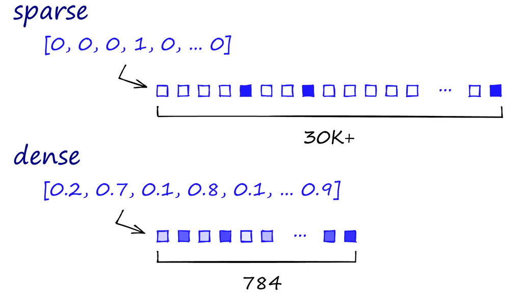

Difference between sparse and dense vectors (matrices)

## Dense vectors

- Distributional hypothesis : words that appear in a similar context tend to have a similar meaning: eg. lawmaker, legislator, politician
- Dense vectors are more efficient than BoW
- **Rationale**: represent words in ~300 dimensions
- **Advantages**:
  - Capture semantic relationships and process synonyms
  - Reduce dimensionality
  - Improve performance/efficiency
  - Transfer learning: pre-trained embeddings can be used in other tasks
- **Disadvantages**:
  - Require large amounts of data to train
  - As unsupervised as it can get, i.e. what do they mean?

## Cosine Similarity

- Cosine similarity: inner product of two non-zero vectors (basically taking the cosine of the angle between two vectors)
  - $[-1; 1]$ where $-1$ = no similarity, $1$ = same word, $0$ = independence (orthogonal)
- Thus, we can place words and their similarity with the help of vectors: $\text{cosine_similarity}(A, B) = \frac{A \cdot B}{||A|| \cdot ||B||}$

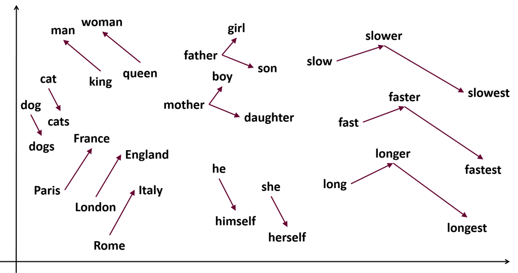

## Word embeddings in practice

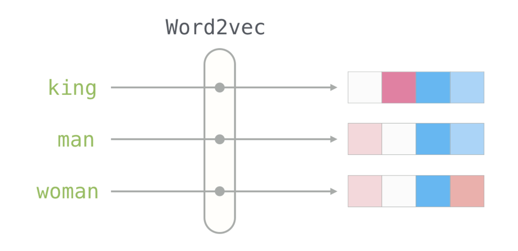

## Word embeddings in practice

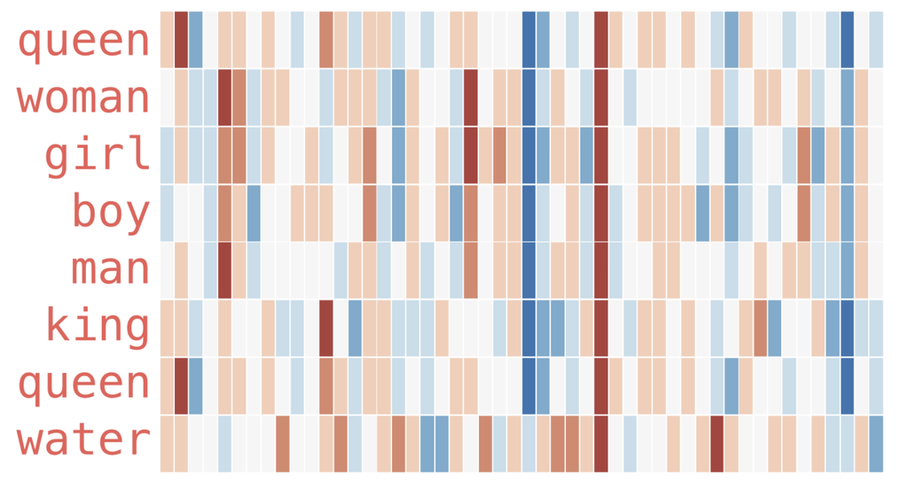

- Example from [Jay Alammar’s GitHub](https://jalammar.github.io/illustrated-word2vec/)

## Three main algorithms

- **word2vec** (Mikolov et al. 2013) (Google 2013)
- **fastText** (Bojanowski et al. 2017) (Facebook 2017)
  - faster than word2vec
  - subword information
- **GloVe** (Pennington, Socher, and Manning 2014) (Stanford 2014)

## Neuralgic points of word embeddings

1. How much context is really context?
2. How many dimensions?
3. Customize corpus or pre-trained corpora?
4. What modeling approach?
5. How to evaluate the embeddings?

## WE decision tree

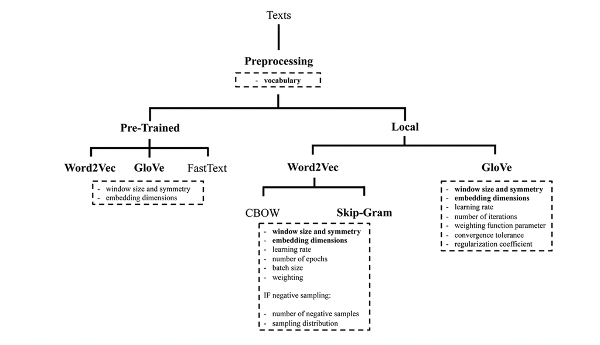

## Textual biases working against WEs

- **Bias**: although used to detect biases and social structure, word embeddings can also reflect and reinforce said biases
  - GloVe is trained on Wikipedia data, but Wikipedia is not free of bias: e.g. gender bias in article authorship or biographical representations (Wagner et al. 2016)
- This Table illustrates racial bias in word embeddings [(taken from a by Speer (2017))](https://blog.conceptnet.io/posts/2017/how-to-make-a-racist-ai-without-really-trying/)

| Phrase | Sentiment Score |
| --- | --- |
| Let’s go get Italian food | 2.0429166109408983 |
| Let’s go get Chinese food | 1.4094033658140972 |
| Let’s go get Mexican food | 0.38801985560121732 |
| My name is Emily | 2.2286179364745311 |
| My name is Heather | 1.3976291151079159 |
| My name is Yvette | 0.98463802132985556 |
| My name is Shaniqua | -0.47048131775890656 |

## Applications of word embeddings

- However, these biases can also intentionally be used for research purposes
- Word embeddings are mathematical representations of words
- Corpora, as mentioned in the first session, are collections of texts *created by social actors in a society*
  - thus, corpora reflect social structure and dynamics
- Word embeddings can be used to analyze these biases

## Garg et al. (2018)

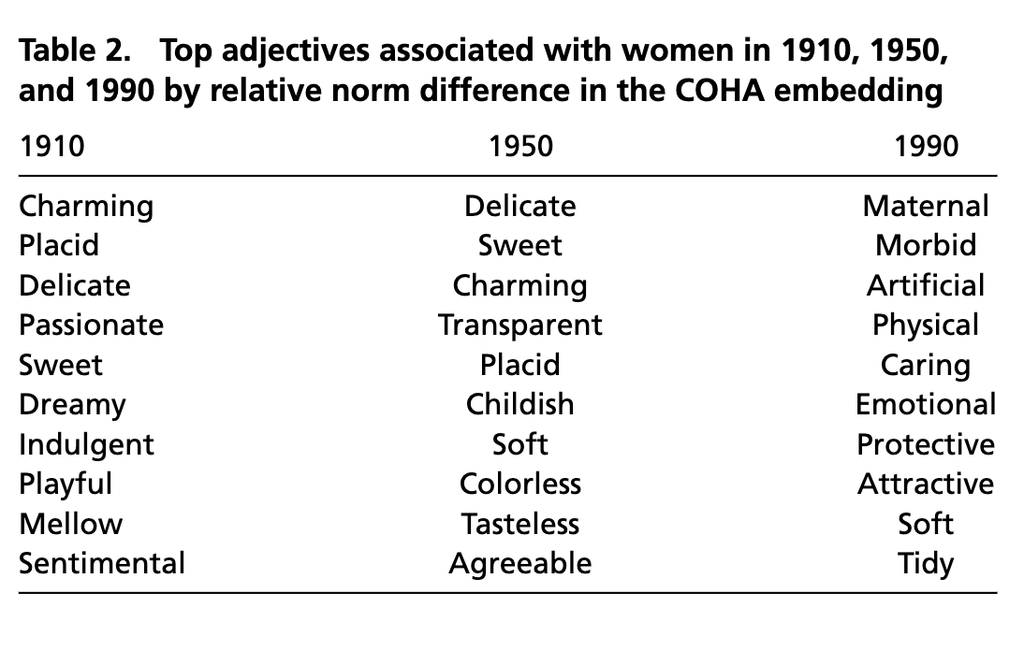

## Garg et al. (2018)

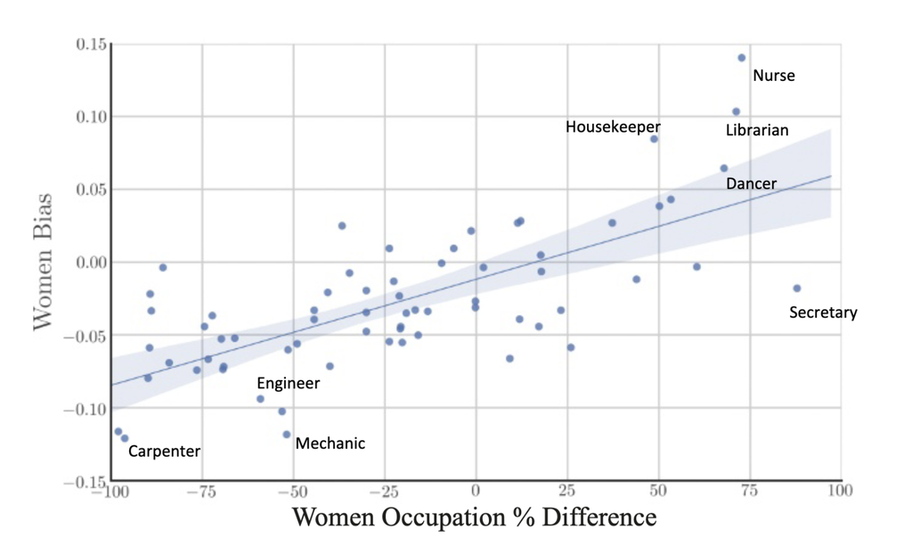

## Garg et al. (2018)

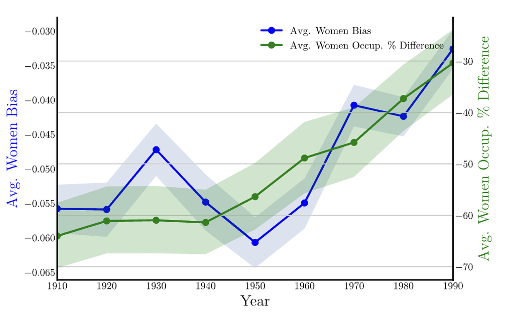

## Shortcomings

- One step away from BoW
- Traditional word embeddings are **static**
  - each word is represented by a single vector that captures the general contexts it typically appears in across the corpus
  - but they do not capture the specific meaning of individual word tokens *in their unique sentence contexts*
- For instance, ”climate” will still have the same representation in different contexts
  1. ”Foreign investors know what a favourable *climate* the United Kingdom provides for manufacturing enterprise.”
  2. ”The Prime Minister signed the Rio convention on *climate* change last June.”
- Word order still does not matter
  1. ”The government serves the people.”
  2. ”The people serve the government.”
- Dimensionality and embedding might be hard to understand

# End of Unsupervised models

## Named Entity Recognition (NER)

- **Attention**: NER does not count as an unsupervised approach!
- They are trained on *labeled* data (human intervention)
- But the method is in my Top 3 of ML methods

## Named Entity Recognition (NER)

- An NLP task to identify and classify entities in text
- Depends on the NER model but here are the typical entities they detect:

| **Entity Type** | **Examples** |
| --- | --- |
| Person/Names | John Doe |
| Organizations | United Nations, Google |
| Locations | Paris, Mount Everest |
| Dates/Times | January 15, 2025 |
| Miscellaneous | Product names, monetary values, percentages |

## Named Entity Recignition (NER)

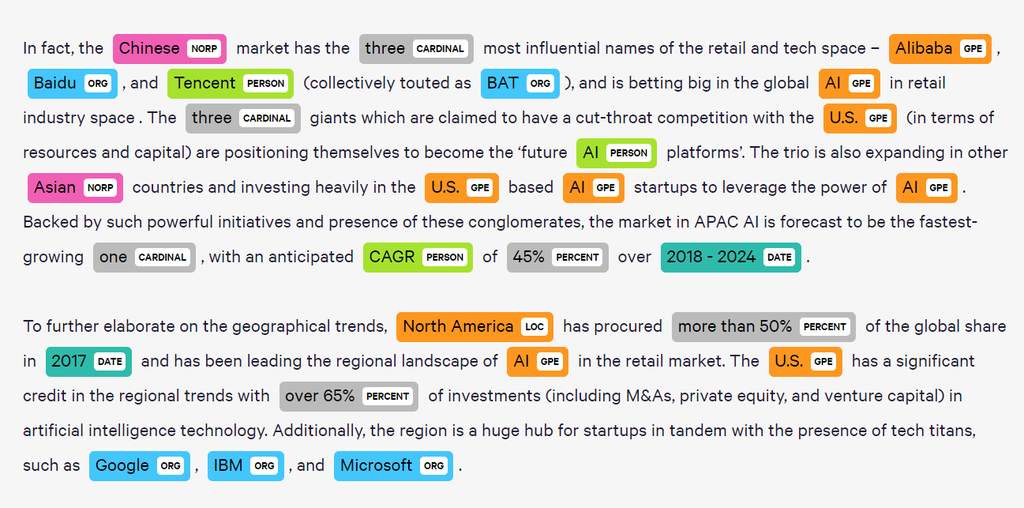

## Use Cases

| Entity Type | Entity | n |
| --- | --- | --- |
| PER | Hitler | 25119 |
| PER | Sohn | 24207 |
| PER | Kohl | 23472 |
| PER | Schröder | 19127 |
| PER | Merkel | 18093 |
| PER | Schmidt | 15862 |
| PER | Helmut Kohl | 12800 |
| PER | Strauß | 12375 |
| PER | Brandt | 11627 |
| PER | Adenauer | 11134 |

## Use Cases

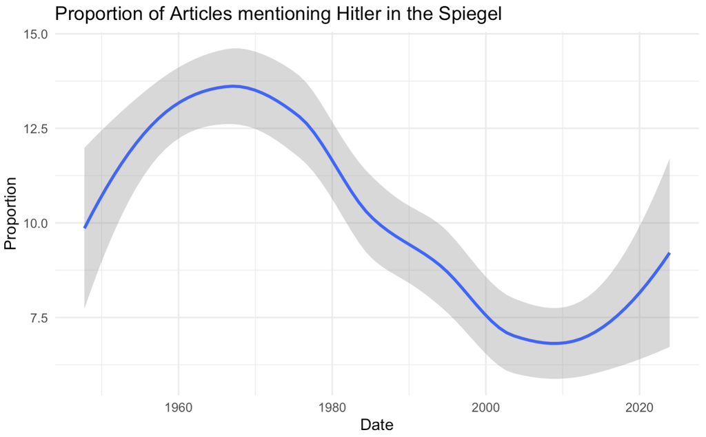

## References

Blei, David M, Andrew Y Ng, and Michael I Jordan. 2003. “Latent Dirichlet Allocation.” *Journal of Machine Learning Research* 3 (Jan): 993–1022.

Bojanowski, Piotr, Edouard Grave, Armand Joulin, and Tomas Mikolov. 2017. “Enriching Word Vectors with Subword Information.” *Transactions of the Association for Computational Linguistics* 5: 135–46.

Firth, J. R. 1957. “A Synopsis of Linguistic Theory, 1930-1955.” *Studies in Linguistic Analysis*, 10–32. https://cir.nii.ac.jp/crid/1574231874045325568.

Garg, Nikhil, Londa Schiebinger, Dan Jurafsky, and James Zou. 2018. “Word Embeddings Quantify 100 Years of Gender and Ethnic Stereotypes.” *Proceedings of the National Academy of Sciences* 115 (16): E3635–44.

Gonzatti, Daniel Saldivia, and Teresa Völker. 2025. “Far-Right Agenda Setting: How the Far Right Influences the Political Mainstream.” *European Journal of Political Research*, 1–23.

Mikolov, Tomas, Ilya Sutskever, Kai Chen, Greg S Corrado, and Jeff Dean. 2013. “Distributed Representations of Words and Phrases and Their Compositionality.” *Advances in Neural Information Processing Systems* 26.

Pennington, Jeffrey, Richard Socher, and Christopher D Manning. 2014. “Glove: Global Vectors for Word Representation.” In *Proceedings of the 2014 Conference on Empirical Methods in Natural Language Processing (EMNLP)*, 1532–43.

Roberts, Margaret E, Brandon M Stewart, Dustin Tingley, Christopher Lucas, Jetson Leder-Luis, Shana Kushner Gadarian, Bethany Albertson, and David G Rand. 2014. “Structural Topic Models for Open-Ended Survey Responses.” *American Journal of Political Science* 58 (4): 1064–82.

Rodriguez, Pedro L, and Arthur Spirling. 2022. “Word Embeddings: What Works, What Doesn’t, and How to Tell the Difference for Applied Research.” *The Journal of Politics* 84 (1): 101–15.

Wagner, Claudia, Eduardo Graells-Garrido, David Garcia, and Filippo Menczer. 2016. “Women Through the Glass Ceiling: Gender Asymmetries in Wikipedia.” *EPJ Data Science* 5: 1–24.